# Lecture 3, Hour 1: Composite Data Frames

08/30/2015

## Last Time

Data frames: the foundation of tidy data analysis. Operations:

- Loading from CSV files, prefab RData files
- selection of rows and columns
- operations grouped by factors

## Today

More advanced operations with data frames:

- "Join" operations
- Hierarchical data construction ("self-joins")

## Basics of a Join

Two data frames with common column names

```r
frame.one <- data.frame (name=c("Alex","Brianna","Cathy"), age = c(34, 29, 27), state = c("ID", "CO", "VT"))
frame.one
```

```
##      name age state
## 1    Alex  34    ID
## 2 Brianna  29    CO
## 3   Cathy  27    VT
```

```r
frame.two <- data.frame (name=c("Brianna","Cathy","Duncan"), sex = c("F","F","M"))
frame.two
```

```
##      name sex
## 1 Brianna   F
## 2   Cathy   F
## 3  Duncan   M
```

```r
frame.three <- data.frame (name=c("Brianna","Cathy","Duncan","Cathy","Cathy"),
                           age = c(29, 26, 5, 27, 27), sex = c("F","F","M","?","F"))
frame.three
```

```
##      name age sex
## 1 Brianna  29   F
## 2   Cathy  26   F
## 3  Duncan   5   M
## 4   Cathy  27   ?
## 5   Cathy  27   F
```

## Join Types

```r
library(dplyr)
frame.one.a <- left_join (frame.one, frame.two)
frame.one.a
```

```
##      name age state  sex
## 1    Alex  34    ID <NA>
## 2 Brianna  29    CO    F
## 3   Cathy  27    VT    F
```

```r
frame.one.b <- left_join (frame.one, frame.three)
frame.one.b
```

```
##      name age state  sex
## 1    Alex  34    ID <NA>
## 2 Brianna  29    CO    F
## 3   Cathy  27    VT    ?
## 4   Cathy  27    VT    F
```

```r
right_join (frame.one, frame.two)
```

```
##      name age state sex
## 1 Brianna  29    CO   F
## 2   Cathy  27    VT   F
## 3  Duncan  NA  <NA>   M
```

```r
right_join (frame.one, frame.three)
```

```
##      name age state sex
## 1 Brianna  29    CO   F
## 2   Cathy  26  <NA>   F
## 3  Duncan   5  <NA>   M
## 4   Cathy  27    VT   ?
## 5   Cathy  27    VT   F
```

## Join Types

```r
inner_join (frame.one, frame.two)
```

```
##      name age state sex
## 1 Brianna  29    CO   F
## 2   Cathy  27    VT   F
```

```r
inner_join (frame.one, frame.three)
```

```
##      name age state sex
## 1 Brianna  29    CO   F
## 2   Cathy  27    VT   ?
## 3   Cathy  27    VT   F
```

```r
full_join (frame.one, frame.two)
```

```
##      name age state  sex
## 1    Alex  34    ID <NA>
## 2 Brianna  29    CO    F
## 3   Cathy  27    VT    F
## 4  Duncan  NA  <NA>    M
```

```r
full_join (frame.one, frame.three)
```

```
##      name age state  sex
## 1    Alex  34    ID <NA>
## 2 Brianna  29    CO    F
## 3   Cathy  27    VT    ?
## 4   Cathy  27    VT    F
## 5   Cathy  26  <NA>    F
## 6  Duncan   5  <NA>    M
```

## "Filter" Joins

```r
semi_join (frame.one, frame.two)
```

```
##      name age state
## 1 Brianna  29    CO
## 2   Cathy  27    VT
```

```r
semi_join (frame.two, frame.one)
```

```
##      name sex
## 1 Brianna   F
## 2   Cathy   F
```

## "Filter" Joins

```r
anti_join (frame.one, frame.two)
```

```
##   name age state
## 1 Alex  34    ID
```

```r
anti_join (frame.two, frame.one)
```

```
##     name sex
## 1 Duncan   M
```

## Older Methods

Compare the old "merge" function:

```r
merge (frame.one, frame.two)
```

```
##      name age state sex
## 1 Brianna  29    CO   F
## 2   Cathy  27    VT   F
```

```r
merge (frame.one, frame.two, all.x = TRUE)
```

```
##      name age state  sex
## 1    Alex  34    ID <NA>
## 2 Brianna  29    CO    F
## 3   Cathy  27    VT    F
```

## Older Methods

Compare the old "merge" function in base R:

```r
merge (frame.one, frame.two, all.y = TRUE)
```

```
##      name age state sex
## 1 Brianna  29    CO   F
## 2   Cathy  27    VT   F
## 3  Duncan  NA  <NA>   M
```

```r
merge (frame.one, frame.two, all.x = TRUE, all.y = TRUE)
```

```
##      name age state  sex
## 1    Alex  34    ID <NA>
## 2 Brianna  29    CO    F
## 3   Cathy  27    VT    F
## 4  Duncan  NA  <NA>    M
```

## Example from R Docs

Which joins are appropriate here?

```r
authors <- data.frame(
    surname = c("Tukey", "Venables", "Tierney", "Ripley", "McNeil"),
    nationality = c("US", "Australia", "US", "UK", "Australia"),
    deceased = c("yes", rep("no", 4)))
books <- data.frame(
    name = c("Tukey", "Venables", "Tierney",
             "Ripley", "Ripley", "McNeil", "R Core"),
    title = c("Exploratory Data Analysis",
              "Modern Applied Statistics ...",
              "LISP-STAT",
              "Spatial Statistics", "Stochastic Simulation",
              "Interactive Data Analysis",
              "An Introduction to R"),
    other.author = c(NA, "Ripley", NA, NA, NA, NA,
                     "Venables & Smith"))
```

## In Base R

```r
m1 <- merge(authors, books, by.x = "surname", by.y = "name")
m1
```

```
##    surname nationality deceased                         title other.author
## 1   McNeil   Australia       no     Interactive Data Analysis         <NA>
## 2   Ripley          UK       no            Spatial Statistics         <NA>
## 3   Ripley          UK       no         Stochastic Simulation         <NA>
## 4  Tierney          US       no                     LISP-STAT         <NA>
## 5    Tukey          US      yes     Exploratory Data Analysis         <NA>
## 6 Venables   Australia       no Modern Applied Statistics ...       Ripley
```

```r
m2 <- merge(books, authors, by.x = "name", by.y = "surname")
m2
```

```
##       name                         title other.author nationality deceased
## 1   McNeil     Interactive Data Analysis         <NA>   Australia       no
## 2   Ripley            Spatial Statistics         <NA>          UK       no
## 3   Ripley         Stochastic Simulation         <NA>          UK       no
## 4  Tierney                     LISP-STAT         <NA>          US       no
## 5    Tukey     Exploratory Data Analysis         <NA>          US      yes
## 6 Venables Modern Applied Statistics ...       Ripley   Australia       no
```

## In dplyr

```r
m3 <- inner_join (authors %>% rename (name = surname),
                  books)
m3
```

```
##       name nationality deceased                         title other.author
## 1    Tukey          US      yes     Exploratory Data Analysis         <NA>
## 2 Venables   Australia       no Modern Applied Statistics ...       Ripley
## 3  Tierney          US       no                     LISP-STAT         <NA>
## 4   Ripley          UK       no            Spatial Statistics         <NA>
## 5   Ripley          UK       no         Stochastic Simulation         <NA>
## 6   McNeil   Australia       no     Interactive Data Analysis         <NA>
```

```r
m4 <- inner_join (books, authors %>% rename (name = surname))
m4
```

```
##       name                         title other.author nationality deceased
## 1    Tukey     Exploratory Data Analysis         <NA>          US      yes
## 2 Venables Modern Applied Statistics ...       Ripley   Australia       no
## 3  Tierney                     LISP-STAT         <NA>          US       no
## 4   Ripley            Spatial Statistics         <NA>          UK       no
## 5   Ripley         Stochastic Simulation         <NA>          UK       no
## 6   McNeil     Interactive Data Analysis         <NA>   Australia       no
```

## Hierarchical Grouping

Consider the data from Homework 1, the subset of the General Social Survey data. We'll expand it a little bit for this class and the subsequent homework.

First, we'll load an augmented version of the GSS:

```r
load ("GSS-extract-2.RData")
head(subGSS.2, 3)
```

```
##   year grass       marital age         degree tvhours radiohrs racmar
## 1 1972  <NA> never married  23       bachelor      NA       NA     no
## 2 1972  <NA>       married  70 lt high school      NA       NA    yes
## 3 1972  <NA>       married  48    high school      NA       NA    yes
##           premarsx marhomo conrinc
## 1 not wrong at all    <NA>      NA
## 2     always wrong    <NA>      NA
## 3     always wrong    <NA>      NA
```

Four variables added: RACMAR (favor laws against interracial marriage), PREMARSX (attitude on premarital sex), MARHOMO (homosexuals should have the right to marry), CONRINC (respondent's income in adjusted dollars)

## External Construction

Let's make a new group and then join it back to the original.

```r
grouped.income <-
  subGSS.2 %>% group_by (year, degree) %>% summarize (income = mean(conrinc, na.rm=TRUE))
```

Examine it:

```r
library(tidyr)
##grouped.income %>% spread (degree, income)
income.table <- grouped.income %>% filter (!is.na(degree)) %>% spread (degree, income)
```

[output not shown]

## External Construction

```r
GSS.augmented <- left_join (subGSS.2, grouped.income) %>% filter (!is.na (income))
head(GSS.augmented)
```

```
##   year grass       marital age         degree tvhours radiohrs racmar
## 1 1974  <NA>       married  21    high school      NA       NA     no
## 2 1974  <NA>       married  41       bachelor      NA       NA    yes
## 3 1974  <NA>       widowed  83 lt high school      NA       NA    yes
## 4 1974  <NA>       widowed  69 lt high school      NA       NA    yes
## 5 1974  <NA> never married  58    high school      NA       NA    yes
## 6 1974  <NA>       married  30       bachelor      NA       NA     no
##           premarsx marhomo conrinc   income
## 1     always wrong    <NA>    6754 27634.61
## 2     always wrong    <NA>   59102 36415.07
## 3     always wrong    <NA>      NA 24332.40
## 4             <NA>    <NA>      NA 24332.40
## 5     always wrong    <NA>   25329 27634.61
## 6 not wrong at all    <NA>   30395 36415.07
```

## Could Do It In One, Here

```r
GSS.augmented.other <-
  subGSS.2 %>% group_by (year, degree) %>% mutate (income = mean(conrinc, na.rm=TRUE)) %>% filter (!is.na (income))
GSS.augmented.other
```

```
## Source: local data frame [55,737 x 12]
## Groups: year, degree [152]
##
##     year  grass marital   age         degree tvhours radiohrs racmar
##    (int) (fctr)  (fctr) (int)         (fctr)   (int)    (int) (fctr)
## 1   1974     NA married    41       bachelor      NA       NA    yes
## 2   1974     NA widowed    83 lt high school      NA       NA    yes
## 3   1974     NA widowed    69 lt high school      NA       NA    yes
## 4   1974     NA married    30       bachelor      NA       NA     no
## 5   1974     NA married    48       graduate      NA       NA     no
## 6   1974     NA married    67 lt high school      NA       NA    yes
## 7   1974     NA married    54 lt high school      NA       NA     no
## 8   1974     NA married    89 lt high school      NA       NA     NA
## 9   1974     NA married    71 lt high school      NA       NA     NA
## 10  1974     NA married    27 lt high school      NA       NA     NA
## ..   ...    ...     ...   ...            ...     ...      ...    ...
## Variables not shown: premarsx (fctr), marhomo (fctr), conrinc (dbl),
##   income (dbl)
```

## Introduction to Base R Graphics

Next week we'll get into more detail about `ggplot2`, the plotting system that's also built by Hadley Wickham, and how the "grammar" of that system works here. For now, let's review the plotting options we have available in Base R.

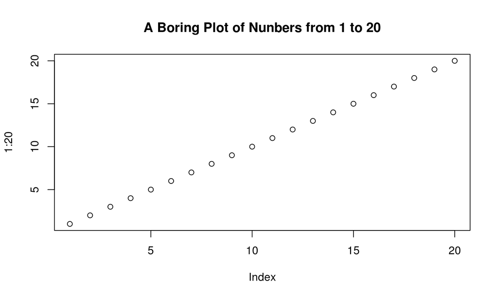

```r
plot (1:20, main="A Boring Plot of Nunbers from 1 to 20")
```

## Introduction to Base R Graphics

Basic principles of statistical graphics: Compare and Contrast different types of data.

Today:

- Single variable, continuous and categorical
- Categorical vs categorical
- Categorical vs continuous

## Introduction to Base R Graphics

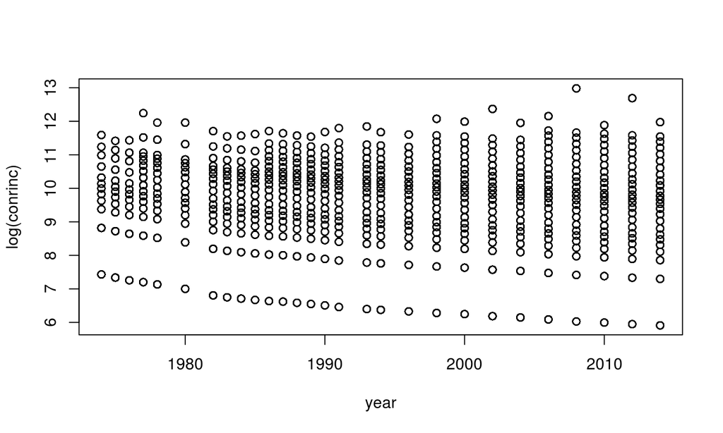

```r
plot (log(conrinc) ~ year, data=GSS.augmented.other)
```

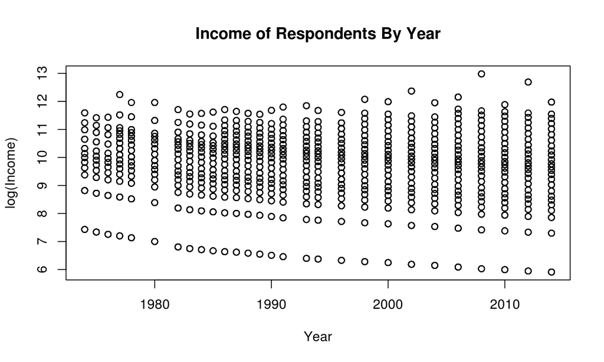

```r
plot (GSS.augmented.other$year, log(GSS.augmented.other$conrinc), main="Income of Respondents By Year", xlab="Year", ylab="log(Income)")
```

## Introduction to Base R Graphics

Basic one-dimensional bar plot:

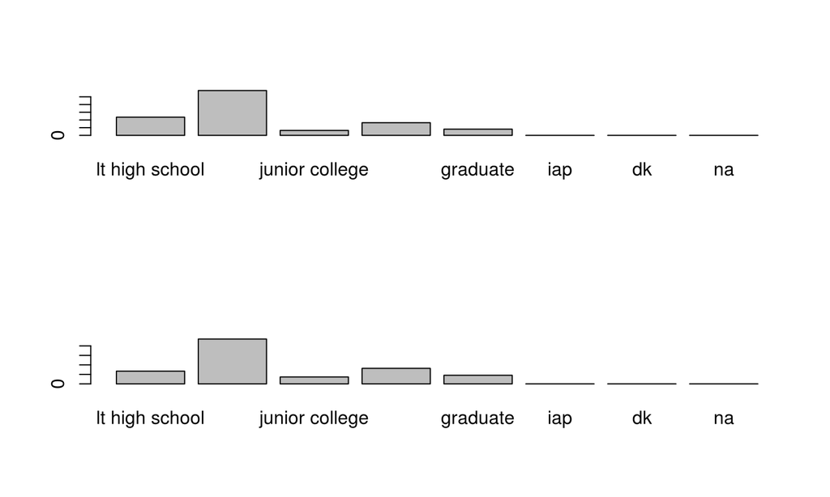

```r
par(mfrow=c(2,1))
plot (GSS.augmented$degree)
plot (GSS.augmented$degree[GSS.augmented$year > 2000])
```

## One-D Numerical Data

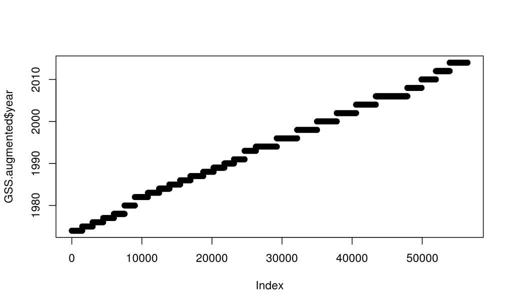

```r
par(mfrow=c(1,1))
plot (GSS.augmented$year)
```

## One-D Numerical Data

Could do better.

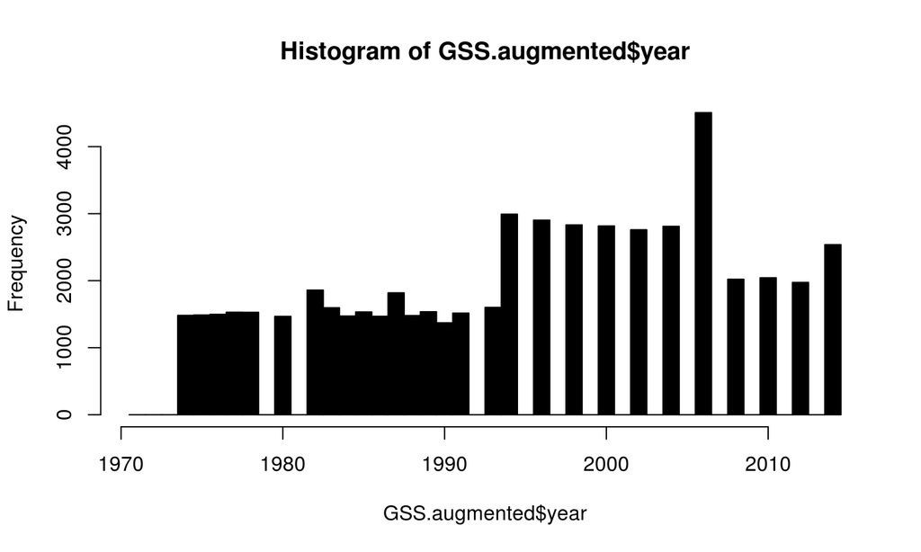

```r
hist (GSS.augmented$year, breaks=seq(1970.5, 2014.5),
      col=1)
```

## Introduction to Base R Graphics

Unhelpful:

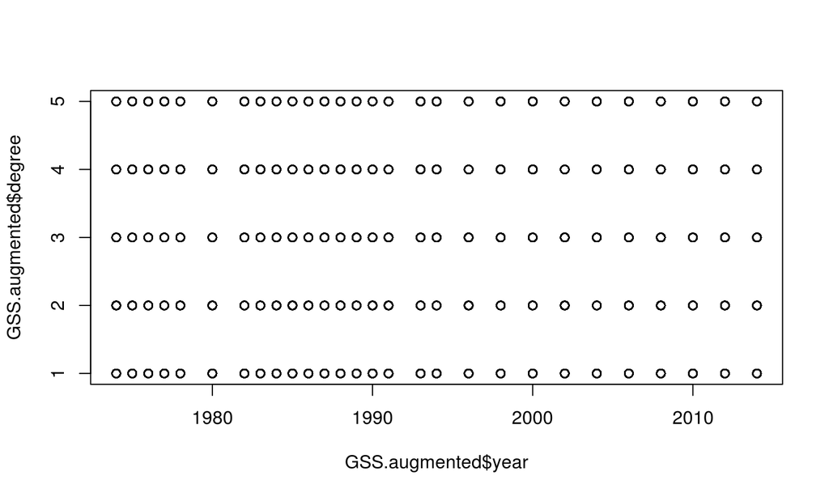

```r
plot (GSS.augmented$year, GSS.augmented$degree)
```

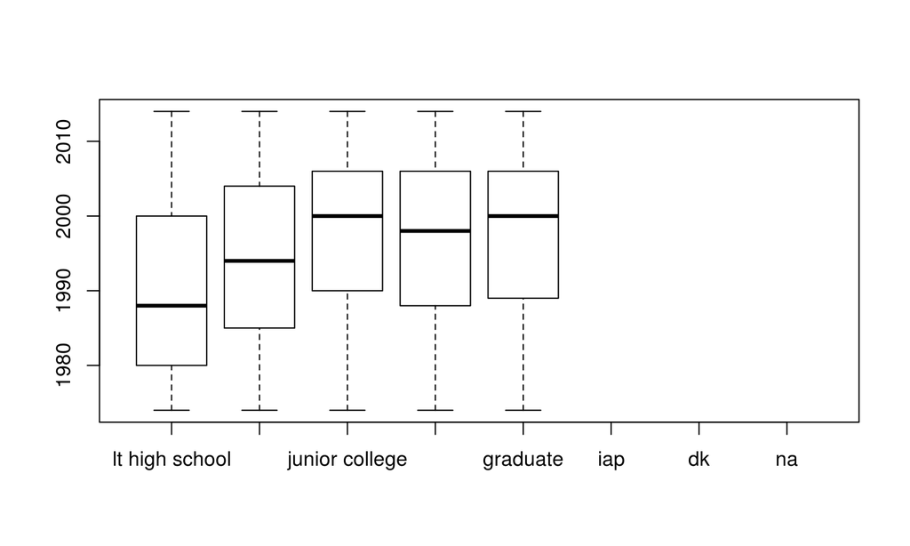

```r
plot (GSS.augmented$degree, GSS.augmented$year)
```

## Introduction to Base R Graphics

More helpful: Mosaic Plot for Categorical vs Categorical

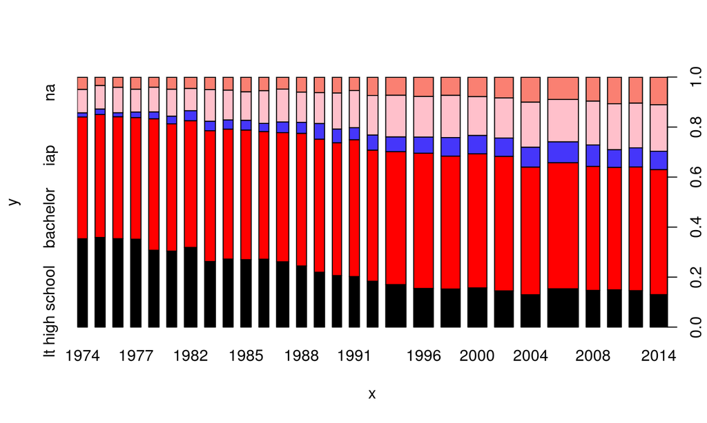

```r
plot (as.factor(GSS.augmented$year), GSS.augmented$degree,
      col=c("black","red","#4536FA","pink","salmon"))
```

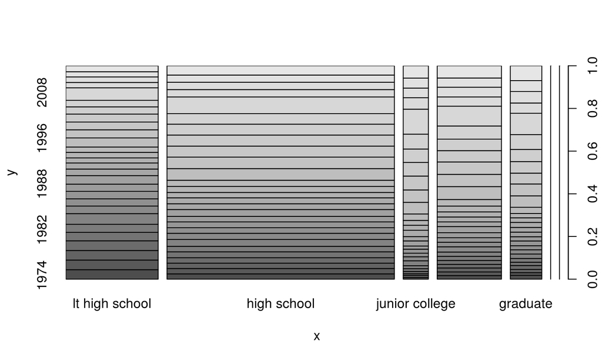

```r
plot (GSS.augmented$degree, as.factor(GSS.augmented$year))
```

## Categorical Versus Continuous

Box plots for continuous outcomes

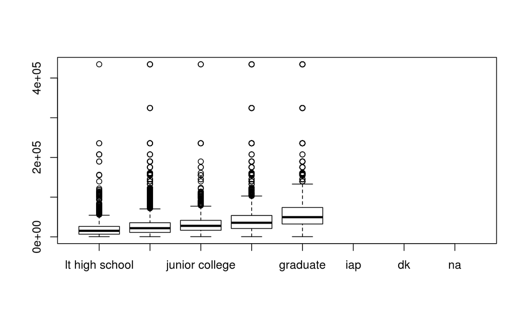

```r
plot (GSS.augmented$degree, GSS.augmented$conrinc)
```

## Categorical Versus Continuous

Box plots for continuous outcomes

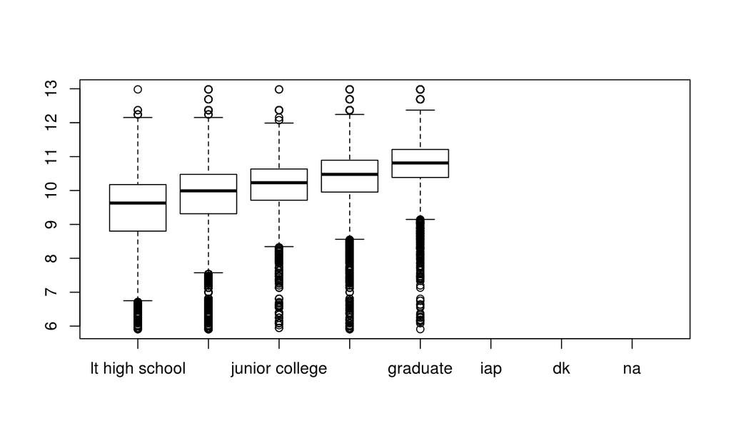

```r
plot (GSS.augmented$degree, log(GSS.augmented$conrinc))
```

## Introduction to Base R Graphics

## Today's Exercises

1. From last time: For each year in the study and degree category, filter down to a new data frame with (at most) the top 10 personal income earners in each group. Confirm the dimensions of this new data frame.
2. Using this, create a new data frame that calculates the fraction of approval of marijuana legalization, the approval of gay marriage, and the approval of both together, for each year and degree group.
3. Display this in a table year over year.
4. Join this back to the data frame `GSS.augmented.other`. (We'll use this more in future exercises.)
5. Make 3 plots comparing the continuous and categorical variables in the "top 10" reduced data set to see if the upper tails show considerably different behaviour than the whole population.